# MiniProject3

Sammit Bal, Jason Zheng, Thaddeus

2025-04-27

## Frontmatter

```r
#remove(list = ls())
# All Libraries
library(glmnet)
```

```r
library(rpart)
library(rattle) # for the fancyRpartPlot()
library(tidyverse)
library(readxl)
library(gridExtra)
# The Dataset
COD_dataset <- read_excel("./CODGames2_mp.xlsx")

# WinLoss = 1 (Win), 0 (Loss)
COD_dataset <- COD_dataset %>%
  # Creating integers PlayerScore and OtherScore
  separate(Result,
           into = c("PlayerScore", "OtherScore"),
           sep = "-") %>%
  mutate(PlayerScore = as.integer(PlayerScore)) %>%
  mutate(OtherScore = as.integer(OtherScore)) %>%
  # Restoring "Result" variable
  mutate(Result = COD_dataset$Result) %>%
  mutate(WinLoss = ifelse(PlayerScore > OtherScore, "Win", "Loss")) %>%
  mutate(WinLossNum = as.factor(ifelse(WinLoss == "Win", 1, 0)))
```

## Task 1: TotalXP + XPType

After removing the cases in which the player only participated in a fraction of the match, create side-by-side boxplots showing the relationship between TotalXP and XPType. (Be sure to use proper axis labels rather than the variable names.) Supplement the plots with summary statistics of TotalXP for each level of XPType. What have you learned about the relationship between XPType and TotalXP?

```r
COD_dataset %>%
  filter(FullPartial == "Full")
```

```
## # A tibble: 191 × 31
##    Map1         Map2  Choice MapVote Date                FullPartial PlayerScore
##    <chr>        <chr> <chr>  <chr>   <dttm>              <chr>             <int>
##  1 Moscow       Miam… Miami… 5 to 0  2022-06-06 00:00:00 Full                100
##  2 Moscow       WMD   Moscow 2 to 0  2022-06-06 00:00:00 Full                 76
##  3 <NA>         <NA>  Yaman… <NA>    2022-06-06 00:00:00 Full                100
##  4 Drive-In     Jung… Drive… 2 to 0  2022-06-06 00:00:00 Full                 80
##  5 Collateral … Hija… Colla… 3 to 3  2022-06-06 00:00:00 Full                 71
##  6 Crossroads … Raid  Raid   4 to 3  2022-06-06 00:00:00 Full                 85
##  7 <NA>         <NA>  WMD    <NA>    2022-06-06 00:00:00 Full                 86
##  8 The Pines    Stan… Stand… 5 to 1  2022-06-06 00:00:00 Full                100
##  9 Echelon      Depr… Depro… 1 to 0  2022-06-12 00:00:00 Full                 46
## 10 Nuketown '84 Hija… Nuket… 1 to 1  2022-06-12 00:00:00 Full                 47
## # ℹ 181 more rows
## # ℹ 24 more variables: OtherScore <int>, Eliminations <dbl>, Deaths <dbl>,
## #   Score <dbl>, Damage <dbl>, TotalXP <dbl>, PrimaryWeapon <chr>,
## #   XPType <chr>, DidPlayerVote <chr>, GameType <chr>, Confirms <dbl>,
## #   Denies <dbl>, Objectives <dbl>, ObjectiveKills <dbl>, Captures <dbl>,
## #   Diffuses <lgl>, Plants <lgl>, Detonates <lgl>, Deposits <lgl>,
## #   Time_Sec <dbl>, Time_Min <dbl>, Result <chr>, WinLoss <chr>, …
```

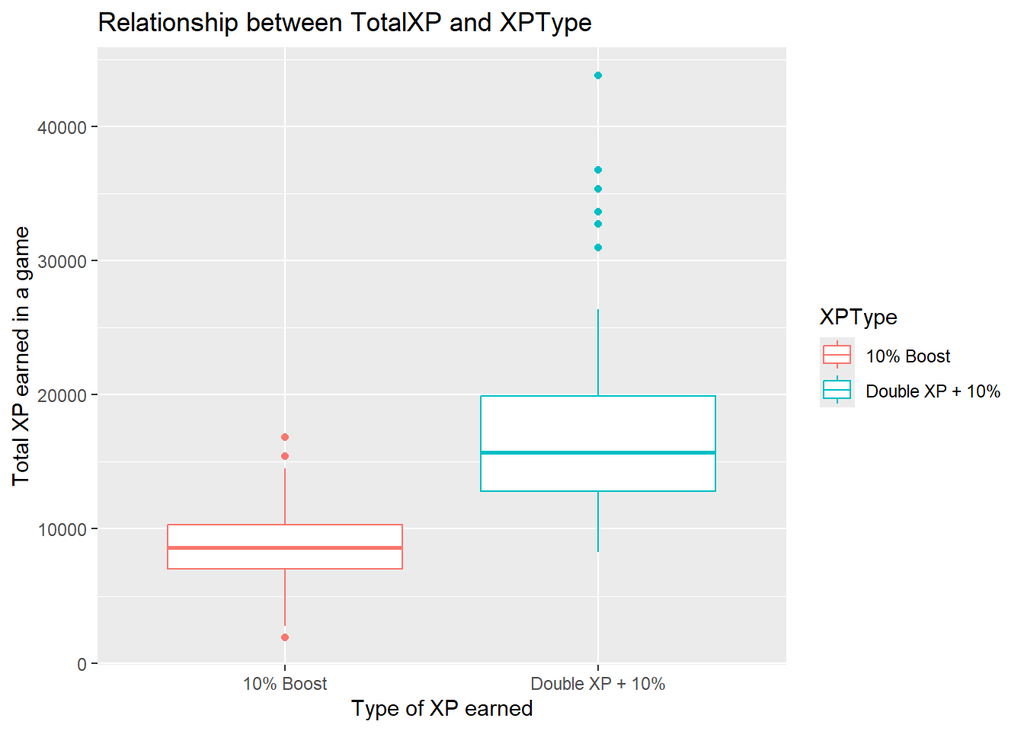

```r
xpType <-ggplot(COD_dataset, aes(x = XPType,
                        y = TotalXP,
                        color = XPType)) +
  labs(x = "Type of XP earned",
       y = "Total XP earned in a game",
       title = "Relationship between TotalXP and XPType") +
geom_boxplot()

xpType
```

```r
COD_dataset %>%
  group_by(XPType) %>%
  summarise(
    mean_TotalXP = mean(TotalXP, na.rm = TRUE),
    median_TotalXP = median(TotalXP, na.rm = TRUE),
    sd_TotalXP = sd(TotalXP, na.rm = TRUE),
    count = n()
  )
```

```
## # A tibble: 2 × 5
##   XPType          mean_TotalXP median_TotalXP sd_TotalXP count
##   <chr>                  <dbl>          <dbl>      <dbl> <int>
## 1 10% Boost              8756.          8603       2679.   129
## 2 Double XP + 10%       17040.         15710.      6692.    82
```

Based off the graph, Double XP + 10% XP boost have a significantly higher median than just a 10% XP boost. To be exact, the average difference exceeds 7,000 total XP, with the difference of means being 8,284 and median d difference being 7,108 XP to be exact. That’s a 94.6% increase in mean, or 82.6% increase in median.

## Task 2

Suppose we wish to build an appropriate model for modeling the Score variable for games in which the player participated in the full match of a HC – TDM game type. We wish to answer the following research question: Of the predictors total XP, eliminations, deaths, damage, XPType, and whether the player’s team won, which should be included in a model for the Score? To answer this, you will have to create a new variable that indicates whether the player was on the winning team or not. NOTE: Since this is an inference question and we are not worried about how well the model will generalize to new data, there is no need to do a training/validation split in this problem.

### Part (a)

- Implement LASSO regression and one other feature selection procedure that we covered in Lecture 15.
- Include relevant plots, a discussion on which value of lambda you selected, the estimated equation from LASSO and the estimated equation from the second method.
- Discuss/compare the results of LASSO with those of the other method.

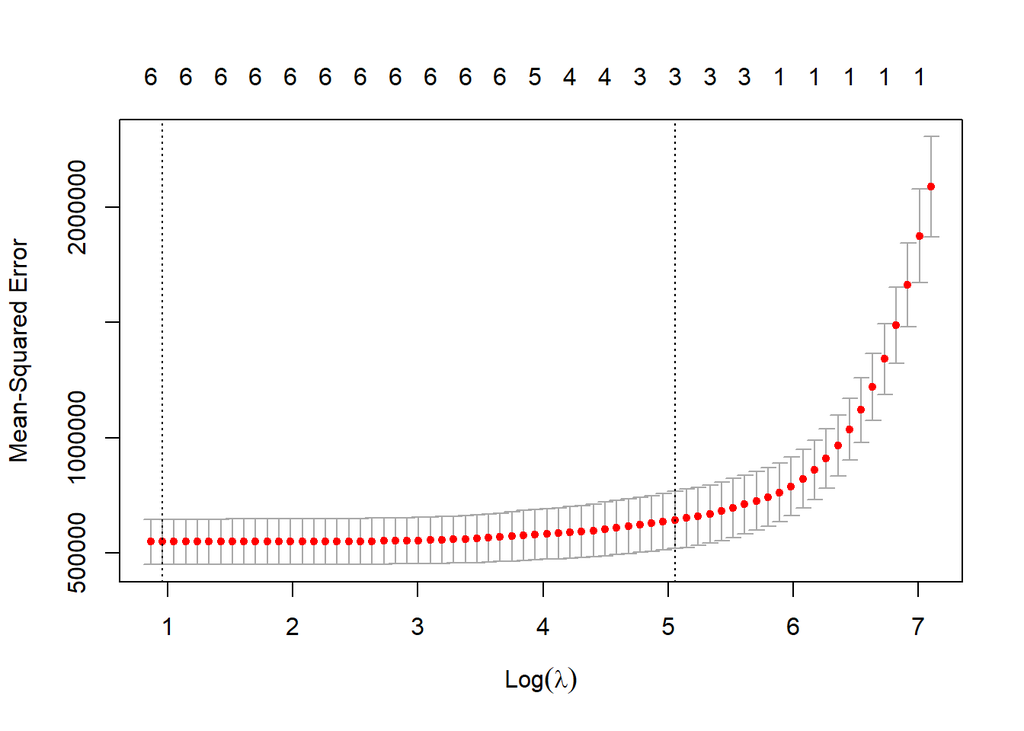

```r
# Selecting for HC-TDM + Full
filtered_data <- COD_dataset %>%
  filter(GameType == "HC - TDM", FullPartial == "Full")

filtered_data <- filtered_data %>%
    mutate(WinLossNum = as.factor(ifelse(WinLoss == "Win", 1, 0)))

# Setting up for LASSO CV
Xmat <- model.matrix(Score ~ TotalXP + Eliminations + Deaths + Damage + XPType + WinLossNum, data = filtered_data)[, -1]
yvec <- filtered_data$Score

# Performing LASSO CV
set.seed(123)
lassoCV <- cv.glmnet(x = Xmat, y = yvec,
                     family = "gaussian",
                     alpha = 1,
                     lambda = NULL,
                     standardize = TRUE,
                     nfolds = 10)
set.seed(NULL)

plot(lassoCV) # View the result!
```

```r
### Selecting which lambda value

lassoCV$lambda.min
```

```
## [1] 2.611974
```

```r
lassoCV$lambda.1se
```

```
## [1] 156.5837
```

```r
# Store the coefficients associated with the optimal values
coefLamMin <- predict(lassoCV, s = lassoCV$lambda.min, type = "coefficients")
coefLam1se <- predict(lassoCV, s = lassoCV$lambda.1se, type = "coefficients")

# Create a data frame for comparing the coefficients
tempdf <-
  data.frame(Variable = row.names(coefLamMin),
             lamMin = as.numeric(coefLamMin),
             lam1se = as.numeric(coefLam1se))

tempdf
```

```
##                Variable        lamMin       lam1se
## 1           (Intercept)  937.15693473 573.15793308
## 2               TotalXP    0.05984054   0.01787101
## 3          Eliminations  159.12937918 174.11183540
## 4                Deaths  -72.77820466 -28.97739444
## 5                Damage    0.94772672   0.00000000
## 6 XPTypeDouble XP + 10% -361.57550500   0.00000000
## 7           WinLossNum1 -447.19199686   0.00000000
```

```r
# Evaluating performance of the model (RMSE)
lassoYhat <- predict(lassoCV,
                     s = lassoCV$lambda.min,
                     newx = Xmat)
lassoMSE <- mean((yvec - lassoYhat)^2)
lassoRMSE <- sqrt(lassoMSE)
lassoRMSE
```

```
## [1] 692.9045
```

```r
### Backwards Selection Model
int_only_model <- lm(Score ~ 1,
                     data = filtered_data)

full_model <- lm(Score ~ TotalXP + Eliminations + Deaths + Damage + XPType + WinLossNum,
                 data = filtered_data)

stats::step(object = full_model,
            scope = list(lower = int_only_model, upper = full_model),
            data = filtered_data,
            direction = "backward")
```

```
## Start:  AIC=2342.53
## Score ~ TotalXP + Eliminations + Deaths + Damage + XPType + WinLossNum
##
##                Df Sum of Sq      RSS    AIC
## - Damage        1    119968 85565679 2340.8
## <none>                      85445711 2342.5
## - Eliminations  1   2766940 88212652 2346.2
## - XPType        1   3222207 88667919 2347.1
## - WinLossNum    1   7727591 93173302 2355.9
## - TotalXP       1  10431500 95877211 2361.0
## - Deaths        1  11752728 97198439 2363.5
##
## Step:  AIC=2340.78
## Score ~ TotalXP + Eliminations + Deaths + XPType + WinLossNum
##
##                Df Sum of Sq       RSS    AIC
## <none>                       85565679 2340.8
## - XPType        1   3103670  88669349 2345.1
## - WinLossNum    1   7627935  93193614 2354.0
## - TotalXP       1  10318883  95884562 2359.0
## - Deaths        1  11660493  97226172 2361.5
## - Eliminations  1 118217717 203783396 2493.2
```

```
##
## Call:
## lm(formula = Score ~ TotalXP + Eliminations + Deaths + XPType +
##     WinLossNum, data = filtered_data)
##
## Coefficients:
##           (Intercept)                TotalXP           Eliminations
##             944.05302                0.06054              185.24081
##                Deaths  XPTypeDouble XP + 10%            WinLossNum1
##             -73.25104             -367.94000             -454.44701
```

```r
# Calculating RMSE
rss <- sum(residuals(full_model)^2)
n <- nobs(full_model)

rmse <- sqrt(rss / n)
rmse
```

```
## [1] 692.8435
```

**Discussion:**

The estimated equation for Lasso is: $\hat(y) = 937.15693473 + 0.05984054x_(TotalXP) + 159.12937918x_(Eliminations) + -72.77820466x_(Deaths) + 0.94772672x_(Damage) + -361.57550500x_(XPTypeDouble XP) + -447.19199686x_(WinLossNum1)$

The estimated equation for Backward Elimination is: $\hat(y) = 944.05302 + 0.06054x_(TotalXP) + 185.24081x_(Eliminations) + -73.25104x_(Deaths) + -367.94000x_(XPTypeDouble XP) + -454.44701x_(WinLossNum1)$

The lambda I selected was 2.611974 which came from the min lambda. I chose this because it resulted in a better RMSE value.

Looking at the variables both methods selected is also interesting. Both methods kept TotalXP, Eliminations, Deaths, XPTypeDouble XP, and WinLossNum1. The one variable the left out in Backward Elimination was damage. This is expected behavior as LASSO tends to shrink small coefficients like Damage without fully dropping them. While Backward Elimination might drop variables that don’t improve the model. We can also notice how similar both models coefficients are, TotalXP, Deaths, XPTypeDouble XP, and WinLossNum1 are all very close.

### Part (b)

- Build a regression tree for predicting Score using total XP, eliminations, deaths, damage, XPType, and whether the player’s team won.
- Specify that each node must contain at least 15 observations.
- Display the tree and report the variables associated with the 3 highest variable importance values. (Include the variable importance values when mentioning the variables.)

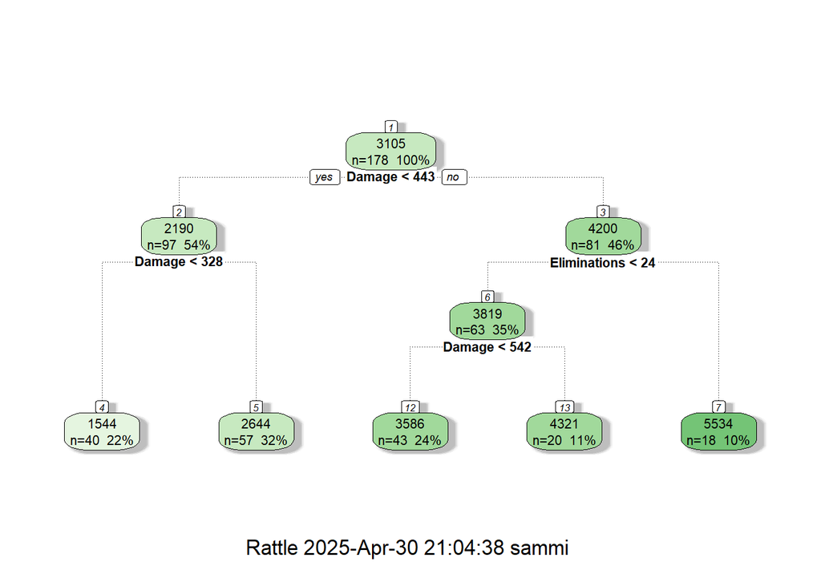

```r
# Creating + Visualizing the regression tree
RegTree <- rpart(Score ~ TotalXP + Eliminations + Deaths + Damage + XPType + WinLossNum,
                 method = "anova", # Regression Tree
                 data = filtered_data,
                 minbucket = 15) # Each node >= 15 observations

fancyRpartPlot(RegTree, cex = 0.7)
```

```r
# Three Most Important Variables
varImps <- 100*RegTree$variable.importance/sum(RegTree$variable.importance)
varImps
```

```
##       Damage Eliminations      TotalXP       Deaths   WinLossNum       XPType
##    39.807799    37.696686    10.216599     6.336862     4.194392     1.747663
```

**Variable Importances:** In the context of a Regression Tree built upon the variables TotalXP, Eliminations, Deaths, Damage, XPType, and WinLossNum (an indicator variable, with 1 meaning the team won, and 0 if they drew or lost), the three most important variables for creating the tree were Damage (39.81%-important to the tree’s creation), Elimination (37.70%-important to the tree’s creation), and TotalXP (10.22%-important to the tree’s creation).

### Part (c)

When building linear regression models, we often wish to determine which variables are the most important. One way of doing this is to look at the magnitude (absolute value) of the estimated coefficients for the regression model built using standardized inputs (centered to have a mean of 0 and a standard deviation of 1).

*Based on the variables selected by the other feature selection procedure from part (a)* (in other words, not the LASSO model)…

1. standardize the inputs,
2. build the regression model,
3. report the estimated equation, and
4. report the 3 most important variables based on the magnitude (absolute value) of the estimated coefficients.

**Question:** How does this compare to the most important variables based on the regression tree?

```r
### Considering the variables from ALT METHOD (backwards selection)
# Predicting: Score ~ TotalXP + Eliminations + Deaths + Damage + XPType + WinLossNum
scaled_filtered_data <- filtered_data %>%
  select(c("Score", "TotalXP", "Eliminations", "Deaths", "Damage", "XPType", "WinLossNum")) %>%
  mutate(XPType = ifelse(XPType == "10% Boost", 0, 1)) %>% # Note: 10% boost is 0, Double is 1
  mutate(WinLossNum = as.numeric(WinLossNum)) %>%
  scale() %>%
  as.data.frame()

### Backward Elimination
int_only_model <- lm(Score ~ 1,
                     data = scaled_filtered_data)

full_model <- lm(Score ~ .,
                 data = scaled_filtered_data)

stats::step(object = full_model,
            scope = list(lower = int_only_model, upper = full_model),
            data = scaled_filtered_data,
            direction = "backward")
```

```
## Start:  AIC=-248.65
## Score ~ TotalXP + Eliminations + Deaths + Damage + XPType + WinLossNum
##
##                Df Sum of Sq    RSS     AIC
## - Damage        1    0.0571 40.756 -250.40
## <none>                      40.699 -248.65
## - Eliminations  1    1.3179 42.017 -244.98
## - XPType        1    1.5348 42.234 -244.06
## - WinLossNum    1    3.6808 44.380 -235.24
## - TotalXP       1    4.9687 45.668 -230.15
## - Deaths        1    5.5980 46.297 -227.71
##
## Step:  AIC=-250.4
## Score ~ TotalXP + Eliminations + Deaths + XPType + WinLossNum
##
##                Df Sum of Sq    RSS      AIC
## <none>                      40.756 -250.402
## - XPType        1     1.478 42.235 -246.060
## - WinLossNum    1     3.633 44.390 -237.202
## - TotalXP       1     4.915 45.671 -232.135
## - Deaths        1     5.554 46.310 -229.662
## - Eliminations  1    56.309 97.065  -97.939
```

```
##
## Call:
## lm(formula = Score ~ TotalXP + Eliminations + Deaths + XPType +
##     WinLossNum, data = scaled_filtered_data)
##
## Coefficients:
##  (Intercept)       TotalXP  Eliminations        Deaths        XPType
##   -1.088e-16     2.642e-01     7.115e-01    -1.908e-01    -1.262e-01
##   WinLossNum
##   -1.561e-01
```

**Estimated Equation:**

$$\text{Score} = -1.088\text{e}^{-16}+0.2642\cdot\text{TotalXP} +
0.7115\cdot\text{Eliminations} - 0.1908\cdot\text{Deaths} -
0.1262\cdot\text{XPType} - 0.1561\cdot\text{WinlossNum}$$

**Three Most Important Variables:**

*Note:* Determined by the scale of their coefficients relative as a percentage of 1, with the greater (positive *or* negative coefficients) indicating greater significance.

1. Eliminations (0.7115)
2. TotalXP (0.2642)
3. Deaths (0.1908)

**Comparison:** Compared to the variables selected by the regression tree, the variables selected the “Other Feature Selection Procedure”— Backwards Selection— are slightly different.